# Through the Looking Glass

Lewis Carroll

### DRAMATIS PERSONÆ.

(*As arranged before commencement of game.*)

| W PIECES | W PAWNS | R PAWNS | R PIECES |
| --- | --- | --- | --- |
| Tweedledee. | Daisy. | Daisy. | Humpty Dumpty. |
| Unicorn. | Haigha. | Messenger. | Carpenter. |
| Sheep. | Oyster. | Oyster. | Walrus. |
| W. Queen. | “Lily.” | Tiger-lily. | R. Queen. |
| W. King. | Fawn. | Rose. | R. King. |
| Aged man. | Oyster. | Oyster. | Crow. |
| W. Knight. | Hatta. | Frog. | R. Knight. |
| Tweedledum. | Daisy. | Daisy. | Lion. |

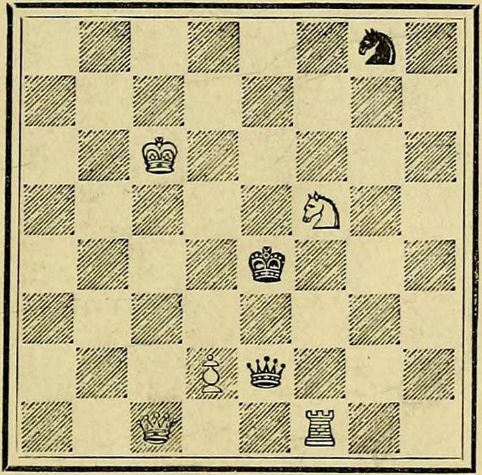

White Pawn (Alice) to play, and win in eleven moves

1. Alice meets R. Q.  
1. R. Q. to K. R.’s 4th  
2. Alice through Q.’s 3d (*by railway*) to 4th (*Tweedledum and Tweedledee*)  
2. W. Q. to Q. B.’s 4th (*after shawl*)  
3. Alice meets W. Q. (*with shawl*)  
3. W. Q. to Q.B.’s 5th (*becomes sheep*)  
4. Alice to Q.’s 5th (*shop, river, shop*)  
4. W. Q. to K. B.’s 8th (*leaves egg on shelf*)  
5. Alice to Q.’s 6th (*Humpty Dumpty*)  
5. W. Q. to Q. B.’s 8th (*flying from R. Kt.*)  
6. Alice to Q.’s 7th (*forest*)  
6. R. Kt. to K.’s 2nd (ch.)  
7. W.Kt. takes R.Kt.  
7. W. Kt. to K. B’s 5th  
8. Alice to Q.’s 8th (*coronation*)  
8. R. Q. to K.’s sq. (*examination*)  
9. Alice becomes Queen  
9. Queens castle  
10. Alice castles (*feast*)  
10. W.Q. to Q.R.’s 6th (*soup*)  
11. Alice takes R.Q. & wins

Child of the pure unclouded brow  
And dreaming eyes of wonder!  
Though time be fleet, and I and thou  
Are half a life asunder,  
Thy loving smile will surely hail  
The love-gift of a fairy-tale.  
I have not seen thy sunny face,  
Nor heard thy silver laughter;  
No thought of me shall find a place  
In thy young life’s hereafter—  
Enough that now thou wilt not fail  
To listen to my fairy-tale.  
A tale begun in other days,  
When summer suns were glowing—  
A simple chime, that served to time  
The rhythm of oar rowing—  
Whose echoes live in memory yet,  
Though envious years would say ‘forget.’  
Come, hearken then, ere voice of dread.  
With bitter tidings laden,  
Shall summon to unwelcome bed  
A melancholy maiden!  
We are but older children, dear,  
Who fret to find our bedtime near.  
Without, the frost, the blinding snow.  
The storm-wind’s moody madness—  
Within, the firelight’s ruddy glow,  
And childhood’s nest of gladness.  
The magic words shall hold thee fast:  
Thou shalt not heed the raving blast.  
And though the shadow of a sigh  
May tremble through the story,  
For ‘happy summer days’ gone by,  
And vanish’d summer glory—  
It shall not touch with breath of bale  
The pleasance of our fairy-tale.

### CHAPTER I. Looking-Glass house

One thing was certain, that the *white* kitten had had nothing to do with it:—it was the black kitten’s fault entirely. For the white kitten had been having its face washed by the old cat for the last quarter of an hour (and bearing it pretty well, considering); so you see that it *couldn’t* have had any hand in the mischief.

The way Dinah washed her children’s faces was this: first she held the poor thing down by its ear with one paw, and then with the other paw she rubbed its face all over, the wrong way, beginning at the nose: and just now, as I said, she was hard at work on the white kitten, which was lying quite still and trying to purr—no doubt feeling that it was all meant for its good.

But the black kitten had been finished with earlier in the afternoon, and so, while Alice was sitting curled up in a corner of the great arm-chair, half talking to herself and half asleep, the kitten had been having a grand game of romps with the ball of worsted Alice had been trying to wind up, and had been rolling it up and down till it had all come undone again; and there it was, spread over the hearth-rug, all knots and tangles, with the kitten running after its own tail in the middle.

“Oh, you wicked little thing!” cried Alice, catching up the kitten, and giving it a little kiss to make it understand that it was in disgrace. “Really, Dinah ought to have taught you better manners! You *ought*, Dinah, you know you ought!” she added, looking reproachfully at the old cat, and speaking in as cross a voice as she could manage—and then she scrambled back into the arm-chair, taking the kitten and the worsted with her, and began winding up the ball again. But she didn’t get on very fast, as she was talking all the time, sometimes to the kitten, and sometimes to herself. Kitty sat very demurely on her knee, pretending to watch the progress of the winding, and now and then putting out one paw and gently touching the ball, as if it would be glad to help, if it might.

“Do you know what to-morrow is, Kitty?” Alice began. “You’d have guessed if you’d been up in the window with me—only Dinah was making you tidy, so you couldn’t. I was watching the boys getting in sticks for the bonfire—and it wants plenty of sticks, Kitty! Only it got so cold, and it snowed so, they had to leave off. Never mind, Kitty, we’ll go and see the bonfire to-morrow.” Here Alice wound two or three turns of the worsted round the kitten’s neck, just to see how it would look: this led to a scramble, in which the ball rolled down upon the floor, and yards and yards of it got unwound again.

“Do you know, I was so angry, Kitty,” Alice went on as soon as they were comfortably settled again, “when I saw all the mischief you had been doing, I was very nearly opening the window, and putting you out into the snow! And you’d have deserved it, you little mischievous darling! What have you got to say for yourself? Now don’t interrupt me!” she went on, holding up one finger. “I’m going to tell you all your faults. Number one: you squeaked twice while Dinah was washing your face this morning. Now you can’t deny it, Kitty: I heard you! What’s that you say?” (pretending that the kitten was speaking.) “Her paw went into your eye? Well, that’s *your* fault, for keeping your eyes open—if you’d shut them tight up, it wouldn’t have happened. Now don’t make any more excuses, but listen! Number two: you pulled Snowdrop away by the tail just as I had put down the saucer of milk before her! What, you were thirsty, were you? How do you know she wasn’t thirsty too? Now for number three: you unwound every bit of the worsted while I wasn’t looking!

“That’s three faults, Kitty, and you’ve not been punished for any of them yet. You know I’m saving up all your punishments for Wednesday week—Suppose they had saved up all *my* punishments!” she went on, talking more to herself than the kitten. “What *would* they do at the end of a year? I should be sent to prison, I suppose, when the day came. Or—let me see—suppose each punishment was to be going without a dinner: then, when the miserable day came, I should have to go without fifty dinners at once! Well, I shouldn’t mind *that* much! I’d far rather go without them than eat them!

“Do you hear the snow against the window-panes, Kitty? How nice and soft it sounds! Just as if some one was kissing the window all over outside. I wonder if the snow *loves* the trees and fields, that it kisses them so gently? And then it covers them up snug, you know, with a white quilt; and perhaps it says, ‘Go to sleep, darlings, till the summer comes again.’ And when they wake up in the summer, Kitty, they dress themselves all in green, and dance about—whenever the wind blows—oh, that’s very pretty!” cried Alice, dropping the ball of worsted to clap her hands. “And I do so *wish* it was true! I’m sure the woods look sleepy in the autumn, when the leaves are getting brown.

“Kitty, can you play chess? Now, don’t smile, my dear, I’m asking it seriously. Because, when we were playing just now, you watched just as if you understood it: and when I said ‘Check!’ you purred! Well, it *was* a nice check, Kitty, and really I might have won, if it hadn’t been for that nasty Knight, that came wiggling down among my pieces. Kitty, dear, let’s pretend—” And here I wish I could tell you half the things Alice used to say, beginning with her favourite phrase “Let’s pretend.” She had had quite a long argument with her sister only the day before—all because Alice had begun with “Let’s pretend we’re kings and queens;” and her sister, who liked being very exact, had argued that they couldn’t, because there were only two of them, and Alice had been reduced at last to say, “Well, *you* can be one of them then, and *I’ll* be all the rest.” And once she had really frightened her old nurse by shouting suddenly in her ear, “Nurse! Do let’s pretend that I’m a hungry hyaena, and you’re a bone.”

But this is taking us away from Alice’s speech to the kitten. “Let’s pretend that you’re the Red Queen, Kitty! Do you know, I think if you sat up and folded your arms, you’d look exactly like her. Now do try, there’s a dear!” And Alice got the Red Queen off the table, and set it up before the kitten as a model for it to imitate: however, the thing didn’t succeed, principally, Alice said, because the kitten wouldn’t fold its arms properly. So, to punish it, she held it up to the Looking-glass, that it might see how sulky it was—“and if you’re not good directly,” she added, “I’ll put you through into Looking-glass House. How would you like *that*?”

“Now, if you’ll only attend, Kitty, and not talk so much, I’ll tell you all my ideas about Looking-glass House. First, there’s the room you can see through the glass—that’s just the same as our drawing room, only the things go the other way. I can see all of it when I get upon a chair—all but the bit behind the fireplace. Oh! I do so wish I could see *that* bit! I want so much to know whether they’ve a fire in the winter: you never *can* tell, you know, unless our fire smokes, and then smoke comes up in that room too—but that may be only pretence, just to make it look as if they had a fire. Well then, the books are something like our books, only the words go the wrong way; I know that, because I’ve held up one of our books to the glass, and then they hold up one in the other room.

“How would you like to live in Looking-glass House, Kitty? I wonder if they’d give you milk in there? Perhaps Looking-glass milk isn’t good to drink—But oh, Kitty! now we come to the passage. You can just see a little *peep* of the passage in Looking-glass House, if you leave the door of our drawing-room wide open: and it’s very like our passage as far as you can see, only you know it may be quite different on beyond. Oh, Kitty! how nice it would be if we could only get through into Looking-glass House! I’m sure it’s got, oh! such beautiful things in it! Let’s pretend there’s a way of getting through into it, somehow, Kitty. Let’s pretend the glass has got all soft like gauze, so that we can get through. Why, it’s turning into a sort of mist now, I declare! It’ll be easy enough to get through—” She was up on the chimney-piece while she said this, though she hardly knew how she had got there. And certainly the glass *was* beginning to melt away, just like a bright silvery mist.

In another moment Alice was through the glass, and had jumped lightly down into the Looking-glass room. The very first thing she did was to look whether there was a fire in the fireplace, and she was quite pleased to find that there was a real one, blazing away as brightly as the one she had left behind. “So I shall be as warm here as I was in the old room,” thought Alice: “warmer, in fact, because there’ll be no one here to scold me away from the fire. Oh, what fun it’ll be, when they see me through the glass in here, and can’t get at me!”

Then she began looking about, and noticed that what could be seen from the old room was quite common and uninteresting, but that all the rest was as different as possible. For instance, the pictures on the wall next the fire seemed to be all alive, and the very clock on the chimney-piece (you know you can only see the back of it in the Looking-glass) had got the face of a little old man, and grinned at her.

“They don’t keep this room so tidy as the other,” Alice thought to herself, as she noticed several of the chessmen down in the hearth among the cinders: but in another moment, with a little “Oh!” of surprise, she was down on her hands and knees watching them. The chessmen were walking about, two and two!

“Here are the Red King and the Red Queen,” Alice said (in a whisper, for fear of frightening them), “and there are the White King and the White Queen sitting on the edge of the shovel—and here are two castles walking arm in arm—I don’t think they can hear me,” she went on, as she put her head closer down, “and I’m nearly sure they can’t see me. I feel somehow as if I were invisible—”

Here something began squeaking on the table behind Alice, and made her turn her head just in time to see one of the White Pawns roll over and begin kicking: she watched it with great curiosity to see what would happen next.

“It is the voice of my child!” the White Queen cried out as she rushed past the King, so violently that she knocked him over among the cinders. “My precious Lily! My imperial kitten!” and she began scrambling wildly up the side of the fender.

“Imperial fiddlestick!” said the King, rubbing his nose, which had been hurt by the fall. He had a right to be a *little* annoyed with the Queen, for he was covered with ashes from head to foot.

Alice was very anxious to be of use, and, as the poor little Lily was nearly screaming herself into a fit, she hastily picked up the Queen and set her on the table by the side of her noisy little daughter.

The Queen gasped, and sat down: the rapid journey through the air had quite taken away her breath and for a minute or two she could do nothing but hug the little Lily in silence. As soon as she had recovered her breath a little, she called out to the White King, who was sitting sulkily among the ashes, “Mind the volcano!”

“What volcano?” said the King, looking up anxiously into the fire, as if he thought that was the most likely place to find one.

“Blew—me—up,” panted the Queen, who was still a little out of breath. “Mind you come up—the regular way—don’t get blown up!”

Alice watched the White King as he slowly struggled up from bar to bar, till at last she said, “Why, you’ll be hours and hours getting to the table, at that rate. I’d far better help you, hadn’t I?” But the King took no notice of the question: it was quite clear that he could neither hear her nor see her.

So Alice picked him up very gently, and lifted him across more slowly than she had lifted the Queen, that she mightn’t take his breath away: but, before she put him on the table, she thought she might as well dust him a little, he was so covered with ashes.

She said afterwards that she had never seen in all her life such a face as the King made, when he found himself held in the air by an invisible hand, and being dusted: he was far too much astonished to cry out, but his eyes and his mouth went on getting larger and larger, and rounder and rounder, till her hand shook so with laughing that she nearly let him drop upon the floor.

“Oh! *please* don’t make such faces, my dear!” she cried out, quite forgetting that the King couldn’t hear her. “You make me laugh so that I can hardly hold you! And don’t keep your mouth so wide open! All the ashes will get into it—there, now I think you’re tidy enough!” she added, as she smoothed his hair, and set him upon the table near the Queen.

The King immediately fell flat on his back, and lay perfectly still: and Alice was a little alarmed at what she had done, and went round the room to see if she could find any water to throw over him. However, she could find nothing but a bottle of ink, and when she got back with it she found he had recovered, and he and the Queen were talking together in a frightened whisper—so low, that Alice could hardly hear what they said.

The King was saying, “I assure, you my dear, I turned cold to the very ends of my whiskers!”

To which the Queen replied, “You haven’t got any whiskers.”

“The horror of that moment,” the King went on, “I shall never, *never* forget!”

“You will, though,” the Queen said, “if you don’t make a memorandum of it.”

Alice looked on with great interest as the King took an enormous memorandum-book out of his pocket, and began writing. A sudden thought struck her, and she took hold of the end of the pencil, which came some way over his shoulder, and began writing for him.

The poor King looked puzzled and unhappy, and struggled with the pencil for some time without saying anything; but Alice was too strong for him, and at last he panted out, “My dear! I really *must* get a thinner pencil. I can’t manage this one a bit; it writes all manner of things that I don’t intend—”

“What manner of things?” said the Queen, looking over the book (in which Alice had put “*The White Knight is sliding down the poker. He balances very badly*”) “That’s not a memorandum of *your* feelings!”

There was a book lying near Alice on the table, and while she sat watching the White King (for she was still a little anxious about him, and had the ink all ready to throw over him, in case he fainted again), she turned over the leaves, to find some part that she could read, “—for it’s all in some language I don’t know,” she said to herself.

It was like this.

**.YKCOWREBBAJ**  
sevot yhtils eht dna, gillirb sawT’  
ebaw eht ni elbmig dna eryg diD  
,sevogorob eht erew ysmim llA  
.ebargtuo shtar emom eht dnA

She puzzled over this for some time, but at last a bright thought struck her. “Why, it’s a Looking-glass book, of course! And if I hold it up to a glass, the words will all go the right way again.”

This was the poem that Alice read.

**JABBERWOCKY.**  
’Twas brillig, and the slithy toves  
Did gyre and gimble in the wabe;  
All mimsy were the borogoves,  
And the mome raths outgrabe.  
“Beware the Jabberwock, my son!  
The jaws that bite, the claws that catch!  
Beware the Jubjub bird, and shun  
The frumious Bandersnatch!”  
He took his vorpal sword in hand:  
Long time the manxome foe he sought—  
So rested he by the Tumtum tree,  
And stood awhile in thought.  
And as in uffish thought he stood,  
The Jabberwock, with eyes of flame,  
Came whiffling through the tulgey wood,  
And burbled as it came!  
One, two! One, two! And through and through  
The vorpal blade went snicker-snack!  
He left it dead, and with its head  
He went galumphing back.  
“And hast thou slain the Jabberwock?  
Come to my arms, my beamish boy!  
O frabjous day! Callooh! Callay!”  
He chortled in his joy.  
’Twas brillig, and the slithy toves  
Did gyre and gimble in the wabe;  
All mimsy were the borogoves,  
And the mome raths outgrabe.

“It seems very pretty,” she said when she had finished it, “but it’s *rather* hard to understand!” (You see she didn’t like to confess, even to herself, that she couldn’t make it out at all.) “Somehow it seems to fill my head with ideas—only I don’t exactly know what they are! However, *somebody* killed *something*: that’s clear, at any rate—”

“But oh!” thought Alice, suddenly jumping up, “if I don’t make haste I shall have to go back through the Looking-glass, before I’ve seen what the rest of the house is like! Let’s have a look at the garden first!” She was out of the room in a moment, and ran down stairs—or, at least, it wasn’t exactly running, but a new invention of hers for getting down stairs quickly and easily, as Alice said to herself. She just kept the tips of her fingers on the hand-rail, and floated gently down without even touching the stairs with her feet; then she floated on through the hall, and would have gone straight out at the door in the same way, if she hadn’t caught hold of the door-post. She was getting a little giddy with so much floating in the air, and was rather glad to find herself walking again in the natural way.

### CHAPTER II. The Garden of Live Flowers

“I should see the garden far better,” said Alice to herself, “if I could get to the top of that hill: and here’s a path that leads straight to it—at least, no, it doesn’t do that—” (after going a few yards along the path, and turning several sharp corners), “but I suppose it will at last. But how curiously it twists! It’s more like a corkscrew than a path! Well, *this* turn goes to the hill, I suppose—no, it doesn’t! This goes straight back to the house! Well then, I’ll try it the other way.”

And so she did: wandering up and down, and trying turn after turn, but always coming back to the house, do what she would. Indeed, once, when she turned a corner rather more quickly than usual, she ran against it before she could stop herself.

“It’s no use talking about it,” Alice said, looking up at the house and pretending it was arguing with her. “I’m *not* going in again yet. I know I should have to get through the Looking-glass again—back into the old room—and there’d be an end of all my adventures!”

So, resolutely turning her back upon the house, she set out once more down the path, determined to keep straight on till she got to the hill. For a few minutes all went on well, and she was just saying, “I really *shall* do it this time—” when the path gave a sudden twist and shook itself (as she described it afterwards), and the next moment she found herself actually walking in at the door.

“Oh, it’s too bad!” she cried. “I never saw such a house for getting in the way! Never!”

However, there was the hill full in sight, so there was nothing to be done but start again. This time she came upon a large flower-bed, with a border of daisies, and a willow-tree growing in the middle.

“O Tiger-lily,” said Alice, addressing herself to one that was waving gracefully about in the wind, “I *wish* you could talk!”

“We *can* talk,” said the Tiger-lily: “when there’s anybody worth talking to.”

Alice was so astonished that she could not speak for a minute: it quite seemed to take her breath away. At length, as the Tiger-lily only went on waving about, she spoke again, in a timid voice—almost in a whisper. “And can *all* the flowers talk?”

“As well as *you* can,” said the Tiger-lily. “And a great deal louder.”

“It isn’t manners for us to begin, you know,” said the Rose, “and I really was wondering when you’d speak! Said I to myself, ‘Her face has got *some* sense in it, though it’s not a clever one!’ Still, you’re the right colour, and that goes a long way.”

“I don’t care about the colour,” the Tiger-lily remarked. “If only her petals curled up a little more, she’d be all right.”

Alice didn’t like being criticised, so she began asking questions. “Aren’t you sometimes frightened at being planted out here, with nobody to take care of you?”

“There’s the tree in the middle,” said the Rose: “what else is it good for?”

“But what could it do, if any danger came?” Alice asked.

“It says ‘Bough-wough!’” cried a Daisy: “that’s why its branches are called boughs!”

“Didn’t you know *that*?” cried another Daisy, and here they all began shouting together, till the air seemed quite full of little shrill voices. “Silence, every one of you!” cried the Tiger-lily, waving itself passionately from side to side, and trembling with excitement. “They know I can’t get at them!” it panted, bending its quivering head towards Alice, “or they wouldn’t dare to do it!”

“Never mind!” Alice said in a soothing tone, and stooping down to the daisies, who were just beginning again, she whispered, “If you don’t hold your tongues, I’ll pick you!”

There was silence in a moment, and several of the pink daisies turned white.

“That’s right!” said the Tiger-lily. “The daisies are worst of all. When one speaks, they all begin together, and it’s enough to make one wither to hear the way they go on!”

“How is it you can all talk so nicely?” Alice said, hoping to get it into a better temper by a compliment. “I’ve been in many gardens before, but none of the flowers could talk.”

“Put your hand down, and feel the ground,” said the Tiger-lily. “Then you’ll know why.”

Alice did so. “It’s very hard,” she said, “but I don’t see what that has to do with it.”

“In most gardens,” the Tiger-lily said, “they make the beds too soft—so that the flowers are always asleep.”

This sounded a very good reason, and Alice was quite pleased to know it. “I never thought of that before!” she said.

“It’s *my* opinion that you never think *at all*,” the Rose said in a rather severe tone.

“I never saw anybody that looked stupider,” a Violet said, so suddenly, that Alice quite jumped; for it hadn’t spoken before.

“Hold *your* tongue!” cried the Tiger-lily. “As if *you* ever saw anybody! You keep your head under the leaves, and snore away there, till you know no more what’s going on in the world, than if you were a bud!”

“Are there any more people in the garden besides me?” Alice said, not choosing to notice the Rose’s last remark.

“There’s one other flower in the garden that can move about like you,” said the Rose. “I wonder how you do it—” (“You’re always wondering,” said the Tiger-lily), “but she’s more bushy than you are.”

“Is she like me?” Alice asked eagerly, for the thought crossed her mind, “There’s another little girl in the garden, somewhere!”

“Well, she has the same awkward shape as you,” the Rose said, “but she’s redder—and her petals are shorter, I think.”

“Her petals are done up close, almost like a dahlia,” the Tiger-lily interrupted: “not tumbled about anyhow, like yours.”

“But that’s not *your* fault,” the Rose added kindly: “you’re beginning to fade, you know—and then one can’t help one’s petals getting a little untidy.”

Alice didn’t like this idea at all: so, to change the subject, she asked “Does she ever come out here?”

“I daresay you’ll see her soon,” said the Rose. “She’s one of the thorny kind.”

“Where does she wear the thorns?” Alice asked with some curiosity.

“Why all round her head, of course,” the Rose replied. “I was wondering *you* hadn’t got some too. I thought it was the regular rule.”

“She’s coming!” cried the Larkspur. “I hear her footstep, thump, thump, thump, along the gravel-walk!”

Alice looked round eagerly, and found that it was the Red Queen. “She’s grown a good deal!” was her first remark. She had indeed: when Alice first found her in the ashes, she had been only three inches high—and here she was, half a head taller than Alice herself!

“It’s the fresh air that does it,” said the Rose: “wonderfully fine air it is, out here.”

“I think I’ll go and meet her,” said Alice, for, though the flowers were interesting enough, she felt that it would be far grander to have a talk with a real Queen.

“You can’t possibly do that,” said the Rose: “*I* should advise you to walk the other way.”

This sounded nonsense to Alice, so she said nothing, but set off at once towards the Red Queen. To her surprise, she lost sight of her in a moment, and found herself walking in at the front-door again.

A little provoked, she drew back, and after looking everywhere for the queen (whom she spied out at last, a long way off), she thought she would try the plan, this time, of walking in the opposite direction.

It succeeded beautifully. She had not been walking a minute before she found herself face to face with the Red Queen, and full in sight of the hill she had been so long aiming at.

“Where do you come from?” said the Red Queen. “And where are you going? Look up, speak nicely, and don’t twiddle your fingers all the time.”

Alice attended to all these directions, and explained, as well as she could, that she had lost her way.

“I don’t know what you mean by *your* way,” said the Queen: “all the ways about here belong to *me*—but why did you come out here at all?” she added in a kinder tone. “Curtsey while you’re thinking what to say, it saves time.”

Alice wondered a little at this, but she was too much in awe of the Queen to disbelieve it. “I’ll try it when I go home,” she thought to herself, “the next time I’m a little late for dinner.”

“It’s time for you to answer now,” the Queen said, looking at her watch: “open your mouth a *little* wider when you speak, and always say ‘your Majesty.’”

“I only wanted to see what the garden was like, your Majesty—”

“That’s right,” said the Queen, patting her on the head, which Alice didn’t like at all, “though, when you say ‘garden,’—*I’ve* seen gardens, compared with which this would be a wilderness.”

Alice didn’t dare to argue the point, but went on: “—and I thought I’d try and find my way to the top of that hill—”

“When you say ‘hill,’” the Queen interrupted, “*I* could show you hills, in comparison with which you’d call that a valley.”

“No, I shouldn’t,” said Alice, surprised into contradicting her at last: “a hill *can’t* be a valley, you know. That would be nonsense—”

The Red Queen shook her head, “You may call it ‘nonsense’ if you like,” she said, “but *I’ve* heard nonsense, compared with which that would be as sensible as a dictionary!”

Alice curtseyed again, as she was afraid from the Queen’s tone that she was a *little* offended: and they walked on in silence till they got to the top of the little hill.

For some minutes Alice stood without speaking, looking out in all directions over the country—and a most curious country it was. There were a number of tiny little brooks running straight across it from side to side, and the ground between was divided up into squares by a number of little green hedges, that reached from brook to brook.

“I declare it’s marked out just like a large chessboard!” Alice said at last. “There ought to be some men moving about somewhere—and so there are!” She added in a tone of delight, and her heart began to beat quick with excitement as she went on. “It’s a great huge game of chess that’s being played—all over the world—if this *is* the world at all, you know. Oh, what fun it is! How I *wish* I was one of them! I wouldn’t mind being a Pawn, if only I might join—though of course I should *like* to be a Queen, best.”

She glanced rather shyly at the real Queen as she said this, but her companion only smiled pleasantly, and said, “That’s easily managed. You can be the White Queen’s Pawn, if you like, as Lily’s too young to play; and you’re in the Second Square to begin with: when you get to the Eighth Square you’ll be a Queen—” Just at this moment, somehow or other, they began to run.

Alice never could quite make out, in thinking it over afterwards, how it was that they began: all she remembers is, that they were running hand in hand, and the Queen went so fast that it was all she could do to keep up with her: and still the Queen kept crying “Faster! Faster!” but Alice felt she *could not* go faster, though she had not breath left to say so.

The most curious part of the thing was, that the trees and the other things round them never changed their places at all: however fast they went, they never seemed to pass anything. “I wonder if all the things move along with us?” thought poor puzzled Alice. And the Queen seemed to guess her thoughts, for she cried, “Faster! Don’t try to talk!”

Not that Alice had any idea of doing *that*. She felt as if she would never be able to talk again, she was getting so much out of breath: and still the Queen cried “Faster! Faster!” and dragged her along. “Are we nearly there?” Alice managed to pant out at last.

“Nearly there!” the Queen repeated. “Why, we passed it ten minutes ago! Faster!” And they ran on for a time in silence, with the wind whistling in Alice’s ears, and almost blowing her hair off her head, she fancied.

“Now! Now!” cried the Queen. “Faster! Faster!” And they went so fast that at last they seemed to skim through the air, hardly touching the ground with their feet, till suddenly, just as Alice was getting quite exhausted, they stopped, and she found herself sitting on the ground, breathless and giddy.

The Queen propped her up against a tree, and said kindly, “You may rest a little now.”

Alice looked round her in great surprise. “Why, I do believe we’ve been under this tree the whole time! Everything’s just as it was!”

“Of course it is,” said the Queen, “what would you have it?”

“Well, in *our* country,” said Alice, still panting a little, “you’d generally get to somewhere else—if you ran very fast for a long time, as we’ve been doing.”

“A slow sort of country!” said the Queen. “Now, *here*, you see, it takes all the running *you* can do, to keep in the same place. If you want to get somewhere else, you must run at least twice as fast as that!”

“I’d rather not try, please!” said Alice. “I’m quite content to stay here—only I *am* so hot and thirsty!”

“I know what *you’d* like!” the Queen said good-naturedly, taking a little box out of her pocket. “Have a biscuit?”

Alice thought it would not be civil to say “No,” though it wasn’t at all what she wanted. So she took it, and ate it as well as she could: and it was *very* dry; and she thought she had never been so nearly choked in all her life.

“While you’re refreshing yourself,” said the Queen, “I’ll just take the measurements.” And she took a ribbon out of her pocket, marked in inches, and began measuring the ground, and sticking little pegs in here and there.

“At the end of two yards,” she said, putting in a peg to mark the distance, “I shall give you your directions—have another biscuit?”

“No, thank you,” said Alice: “one’s *quite* enough!”

“Thirst quenched, I hope?” said the Queen.

Alice did not know what to say to this, but luckily the Queen did not wait for an answer, but went on. “At the end of *three* yards I shall repeat them—for fear of your forgetting them. At the end of *four*, I shall say good-bye. And at the end of *five*, I shall go!”

She had got all the pegs put in by this time, and Alice looked on with great interest as she returned to the tree, and then began slowly walking down the row.

At the two-yard peg she faced round, and said, “A pawn goes two squares in its first move, you know. So you’ll go *very* quickly through the Third Square—by railway, I should think—and you’ll find yourself in the Fourth Square in no time. Well, *that* square belongs to Tweedledum and Tweedledee—the Fifth is mostly water—the Sixth belongs to Humpty Dumpty—But you make no remark?”

“I—I didn’t know I had to make one—just then,” Alice faltered out.

“You *should* have said, ‘It’s extremely kind of you to tell me all this’—however, we’ll suppose it said—the Seventh Square is all forest—however, one of the Knights will show you the way—and in the Eighth Square we shall be Queens together, and it’s all feasting and fun!” Alice got up and curtseyed, and sat down again.

At the next peg the Queen turned again, and this time she said, “Speak in French when you can’t think of the English for a thing—turn out your toes as you walk—and remember who you are!” She did not wait for Alice to curtsey this time, but walked on quickly to the next peg, where she turned for a moment to say “good-bye,” and then hurried on to the last.

How it happened, Alice never knew, but exactly as she came to the last peg, she was gone. Whether she vanished into the air, or whether she ran quickly into the wood (“and she *can* run very fast!” thought Alice), there was no way of guessing, but she was gone, and Alice began to remember that she was a Pawn, and that it would soon be time for her to move.

### CHAPTER III. Looking-Glass Insects

Of course the first thing to do was to make a grand survey of the country she was going to travel through. “It’s something very like learning geography,” thought Alice, as she stood on tiptoe in hopes of being able to see a little further. “Principal rivers—there *are* none. Principal mountains—I’m on the only one, but I don’t think it’s got any name. Principal towns—why, what *are* those creatures, making honey down there? They can’t be bees—nobody ever saw bees a mile off, you know—” and for some time she stood silent, watching one of them that was bustling about among the flowers, poking its proboscis into them, “just as if it was a regular bee,” thought Alice.

However, this was anything but a regular bee: in fact it was an elephant—as Alice soon found out, though the idea quite took her breath away at first. “And what enormous flowers they must be!” was her next idea. “Something like cottages with the roofs taken off, and stalks put to them—and what quantities of honey they must make! I think I’ll go down and—no, I won’t *just* yet,” she went on, checking herself just as she was beginning to run down the hill, and trying to find some excuse for turning shy so suddenly. “It’ll never do to go down among them without a good long branch to brush them away—and what fun it’ll be when they ask me how I like my walk. I shall say—‘Oh, I like it well enough—’” (here came the favourite little toss of the head), “‘only it was so dusty and hot, and the elephants did tease so!’”

“I think I’ll go down the other way,” she said after a pause: “and perhaps I may visit the elephants later on. Besides, I do so want to get into the Third Square!”

So with this excuse she ran down the hill and jumped over the first of the six little brooks.

* * * * * * *  
* * * * * *  
* * * * * * *

“Tickets, please!” said the Guard, putting his head in at the window. In a moment everybody was holding out a ticket: they were about the same size as the people, and quite seemed to fill the carriage.

“Now then! Show your ticket, child!” the Guard went on, looking angrily at Alice. And a great many voices all said together (“like the chorus of a song,” thought Alice), “Don’t keep him waiting, child! Why, his time is worth a thousand pounds a minute!”

“I’m afraid I haven’t got one,” Alice said in a frightened tone: “there wasn’t a ticket-office where I came from.” And again the chorus of voices went on. “There wasn’t room for one where she came from. The land there is worth a thousand pounds an inch!”

“Don’t make excuses,” said the Guard: “you should have bought one from the engine-driver.” And once more the chorus of voices went on with “The man that drives the engine. Why, the smoke alone is worth a thousand pounds a puff!”

Alice thought to herself, “Then there’s no use in speaking.” The voices didn’t join in this time, as she hadn’t spoken, but to her great surprise, they all *thought* in chorus (I hope you understand what *thinking in chorus* means—for I must confess that *I* don’t), “Better say nothing at all. Language is worth a thousand pounds a word!”

“I shall dream about a thousand pounds tonight, I know I shall!” thought Alice.

All this time the Guard was looking at her, first through a telescope, then through a microscope, and then through an opera-glass. At last he said, “You’re travelling the wrong way,” and shut up the window and went away.

“So young a child,” said the gentleman sitting opposite to her (he was dressed in white paper), “ought to know which way she’s going, even if she doesn’t know her own name!”

A Goat, that was sitting next to the gentleman in white, shut his eyes and said in a loud voice, “She ought to know her way to the ticket-office, even if she doesn’t know her alphabet!”

There was a Beetle sitting next to the Goat (it was a very queer carriage-full of passengers altogether), and, as the rule seemed to be that they should all speak in turn, *he* went on with “She’ll have to go back from here as luggage!”

Alice couldn’t see who was sitting beyond the Beetle, but a hoarse voice spoke next. “Change engines—” it said, and was obliged to leave off.

“It sounds like a horse,” Alice thought to herself. And an extremely small voice, close to her ear, said, “You might make a joke on that—something about ‘horse’ and ‘hoarse,’ you know.”

Then a very gentle voice in the distance said, “She must be labelled ‘Lass, with care,’ you know—”

And after that other voices went on (“What a number of people there are in the carriage!” thought Alice), saying, “She must go by post, as she’s got a head on her—” “She must be sent as a message by the telegraph—” “She must draw the train herself the rest of the way—” and so on.

But the gentleman dressed in white paper leaned forwards and whispered in her ear, “Never mind what they all say, my dear, but take a return-ticket every time the train stops.”

“Indeed I shan’t!” Alice said rather impatiently. “I don’t belong to this railway journey at all—I was in a wood just now—and I wish I could get back there.”

“You might make a joke on *that*,” said the little voice close to her ear: “something about ‘you *would* if you could,’ you know.”

“Don’t tease so,” said Alice, looking about in vain to see where the voice came from; “if you’re so anxious to have a joke made, why don’t you make one yourself?”

The little voice sighed deeply: it was *very* unhappy, evidently, and Alice would have said something pitying to comfort it, “If it would only sigh like other people!” she thought. But this was such a wonderfully small sigh, that she wouldn’t have heard it at all, if it hadn’t come *quite* close to her ear. The consequence of this was that it tickled her ear very much, and quite took off her thoughts from the unhappiness of the poor little creature.

“I know you are a friend,” the little voice went on; “a dear friend, and an old friend. And you won’t hurt me, though I *am* an insect.”

“What kind of insect?” Alice inquired a little anxiously. What she really wanted to know was, whether it could sting or not, but she thought this wouldn’t be quite a civil question to ask.

“What, then you don’t—” the little voice began, when it was drowned by a shrill scream from the engine, and everybody jumped up in alarm, Alice among the rest.

The Horse, who had put his head out of the window, quietly drew it in and said, “It’s only a brook we have to jump over.” Everybody seemed satisfied with this, though Alice felt a little nervous at the idea of trains jumping at all. “However, it’ll take us into the Fourth Square, that’s some comfort!” she said to herself. In another moment she felt the carriage rise straight up into the air, and in her fright she caught at the thing nearest to her hand, which happened to be the Goat’s beard.

* * * * * * *  
* * * * * *  
* * * * * * *

But the beard seemed to melt away as she touched it, and she found herself sitting quietly under a tree—while the Gnat (for that was the insect she had been talking to) was balancing itself on a twig just over her head, and fanning her with its wings.

It certainly was a *very* large Gnat: “about the size of a chicken,” Alice thought. Still, she couldn’t feel nervous with it, after they had been talking together so long.

“—then you don’t like all insects?” the Gnat went on, as quietly as if nothing had happened.

“I like them when they can talk,” Alice said. “None of them ever talk, where *I* come from.”

“What sort of insects do you rejoice in, where *you* come from?” the Gnat inquired.

“I don’t *rejoice* in insects at all,” Alice explained, “because I’m rather afraid of them—at least the large kinds. But I can tell you the names of some of them.”

“Of course they answer to their names?” the Gnat remarked carelessly.

“I never knew them to do it.”

“What’s the use of their having names,” the Gnat said, “if they won’t answer to them?”

“No use to *them*,” said Alice; “but it’s useful to the people who name them, I suppose. If not, why do things have names at all?”

“I can’t say,” the Gnat replied. “Further on, in the wood down there, they’ve got no names—however, go on with your list of insects: you’re wasting time.”

“Well, there’s the Horse-fly,” Alice began, counting off the names on her fingers.

“All right,” said the Gnat: “half way up that bush, you’ll see a Rocking-horse-fly, if you look. It’s made entirely of wood, and gets about by swinging itself from branch to branch.”

“What does it live on?” Alice asked, with great curiosity.

“Sap and sawdust,” said the Gnat. “Go on with the list.”

Alice looked up at the Rocking-horse-fly with great interest, and made up her mind that it must have been just repainted, it looked so bright and sticky; and then she went on.

“And there’s the Dragon-fly.”

“Look on the branch above your head,” said the Gnat, “and there you’ll find a snap-dragon-fly. Its body is made of plum-pudding, its wings of holly-leaves, and its head is a raisin burning in brandy.”

“And what does it live on?”

“Frumenty and mince pie,” the Gnat replied; “and it makes its nest in a Christmas box.”

“And then there’s the Butterfly,” Alice went on, after she had taken a good look at the insect with its head on fire, and had thought to herself, “I wonder if that’s the reason insects are so fond of flying into candles—because they want to turn into Snap-dragon-flies!”

“Crawling at your feet,” said the Gnat (Alice drew her feet back in some alarm), “you may observe a Bread-and-Butterfly. Its wings are thin slices of Bread-and-butter, its body is a crust, and its head is a lump of sugar.”

“And what does *it* live on?”

“Weak tea with cream in it.”

A new difficulty came into Alice’s head. “Supposing it couldn’t find any?” she suggested.

“Then it would die, of course.”

“But that must happen very often,” Alice remarked thoughtfully.

“It always happens,” said the Gnat.

After this, Alice was silent for a minute or two, pondering. The Gnat amused itself meanwhile by humming round and round her head: at last it settled again and remarked, “I suppose you don’t want to lose your name?”

“No, indeed,” Alice said, a little anxiously.

“And yet I don’t know,” the Gnat went on in a careless tone: “only think how convenient it would be if you could manage to go home without it! For instance, if the governess wanted to call you to your lessons, she would call out ‘come here—,’ and there she would have to leave off, because there wouldn’t be any name for her to call, and of course you wouldn’t have to go, you know.”

“That would never do, I’m sure,” said Alice: “the governess would never think of excusing me lessons for that. If she couldn’t remember my name, she’d call me ‘Miss!’ as the servants do.”

“Well, if she said ‘Miss,’ and didn’t say anything more,” the Gnat remarked, “of course you’d miss your lessons. That’s a joke. I wish *you* had made it.”

“Why do you wish *I* had made it?” Alice asked. “It’s a very bad one.”

But the Gnat only sighed deeply, while two large tears came rolling down its cheeks.

“You shouldn’t make jokes,” Alice said, “if it makes you so unhappy.”

Then came another of those melancholy little sighs, and this time the poor Gnat really seemed to have sighed itself away, for, when Alice looked up, there was nothing whatever to be seen on the twig, and, as she was getting quite chilly with sitting still so long, she got up and walked on.

She very soon came to an open field, with a wood on the other side of it: it looked much darker than the last wood, and Alice felt a *little* timid about going into it. However, on second thoughts, she made up her mind to go on: “for I certainly won’t go *back*,” she thought to herself, and this was the only way to the Eighth Square.

“This must be the wood,” she said thoughtfully to herself, “where things have no names. I wonder what’ll become of *my* name when I go in? I shouldn’t like to lose it at all—because they’d have to give me another, and it would be almost certain to be an ugly one. But then the fun would be trying to find the creature that had got my old name! That’s just like the advertisements, you know, when people lose dogs—‘*answers to the name of “Dash:” had on a brass collar*’—just fancy calling everything you met ‘Alice,’ till one of them answered! Only they wouldn’t answer at all, if they were wise.”

She was rambling on in this way when she reached the wood: it looked very cool and shady. “Well, at any rate it’s a great comfort,” she said as she stepped under the trees, “after being so hot, to get into the—into *what*?” she went on, rather surprised at not being able to think of the word. “I mean to get under the—under the—under *this*, you know!” putting her hand on the trunk of the tree. “What *does* it call itself, I wonder? I do believe it’s got no name—why, to be sure it hasn’t!”

She stood silent for a minute, thinking: then she suddenly began again. “Then it really *has* happened, after all! And now, who am I? I *will* remember, if I can! I’m determined to do it!” But being determined didn’t help much, and all she could say, after a great deal of puzzling, was, “L, I *know* it begins with L!”

Just then a Fawn came wandering by: it looked at Alice with its large gentle eyes, but didn’t seem at all frightened. “Here then! Here then!” Alice said, as she held out her hand and tried to stroke it; but it only started back a little, and then stood looking at her again.

“What do you call yourself?” the Fawn said at last. Such a soft sweet voice it had!

“I wish I knew!” thought poor Alice. She answered, rather sadly, “Nothing, just now.”

“Think again,” it said: “that won’t do.”

Alice thought, but nothing came of it. “Please, would you tell me what *you* call yourself?” she said timidly. “I think that might help a little.”

“I’ll tell you, if you’ll move a little further on,” the Fawn said. “I can’t remember here.”

So they walked on together though the wood, Alice with her arms clasped lovingly round the soft neck of the Fawn, till they came out into another open field, and here the Fawn gave a sudden bound into the air, and shook itself free from Alice’s arms. “I’m a Fawn!” it cried out in a voice of delight, “and, dear me! you’re a human child!” A sudden look of alarm came into its beautiful brown eyes, and in another moment it had darted away at full speed.

Alice stood looking after it, almost ready to cry with vexation at having lost her dear little fellow-traveller so suddenly. “However, I know my name now.” she said, “that’s *some* comfort. Alice—Alice—I won’t forget it again. And now, which of these finger-posts ought I to follow, I wonder?”

It was not a very difficult question to answer, as there was only one road through the wood, and the two finger-posts both pointed along it. “I’ll settle it,” Alice said to herself, “when the road divides and they point different ways.”

But this did not seem likely to happen. She went on and on, a long way, but wherever the road divided there were sure to be two finger-posts pointing the same way, one marked “TO TWEEDLEDUM’S HOUSE” and the other “TO THE HOUSE OF TWEEDLEDEE.”

“I do believe,” said Alice at last, “that they live in the same house! I wonder I never thought of that before—But I can’t stay there long. I’ll just call and say ‘how d’you do?’ and ask them the way out of the wood. If I could only get to the Eighth Square before it gets dark!” So she wandered on, talking to herself as she went, till, on turning a sharp corner, she came upon two fat little men, so suddenly that she could not help starting back, but in another moment she recovered herself, feeling sure that they must be.

### CHAPTER IV. Tweedledum And Tweedledee

They were standing under a tree, each with an arm round the other’s neck, and Alice knew which was which in a moment, because one of them had “DUM” embroidered on his collar, and the other “DEE.” “I suppose they’ve each got ‘TWEEDLE’ round at the back of the collar,” she said to herself.

They stood so still that she quite forgot they were alive, and she was just looking round to see if the word ‘TWEEDLE’ was written at the back of each collar, when she was startled by a voice coming from the one marked “DUM.”

“If you think we’re wax-works,” he said, “you ought to pay, you know. Wax-works weren’t made to be looked at for nothing, nohow!”

“Contrariwise,” added the one marked “DEE,” “if you think we’re alive, you ought to speak.”

“I’m sure I’m very sorry,” was all Alice could say; for the words of the old song kept ringing through her head like the ticking of a clock, and she could hardly help saying them out loud:—

“Tweedledum and Tweedledee  
Agreed to have a battle;  
For Tweedledum said Tweedledee  
Had spoiled his nice new rattle.  
Just then flew down a monstrous crow,  
As black as a tar-barrel;  
Which frightened both the heroes so,  
They quite forgot their quarrel.”

“I know what you’re thinking about,” said Tweedledum: “but it isn’t so, nohow.”

“Contrariwise,” continued Tweedledee, “if it was so, it might be; and if it were so, it would be; but as it isn’t, it ain’t. That’s logic.”

“I was thinking,” Alice said very politely, “which is the best way out of this wood: it’s getting so dark. Would you tell me, please?”

But the little men only looked at each other and grinned.

They looked so exactly like a couple of great schoolboys, that Alice couldn’t help pointing her finger at Tweedledum, and saying “First Boy!”

“Nohow!” Tweedledum cried out briskly, and shut his mouth up again with a snap.

“Next Boy!” said Alice, passing on to Tweedledee, though she felt quite certain he would only shout out “Contrariwise!” and so he did.

“You’ve been wrong!” cried Tweedledum. “The first thing in a visit is to say ‘How d’ye do?’ and shake hands!” And here the two brothers gave each other a hug, and then they held out the two hands that were free, to shake hands with her.

Alice did not like shaking hands with either of them first, for fear of hurting the other one’s feelings; so, as the best way out of the difficulty, she took hold of both hands at once: the next moment they were dancing round in a ring. This seemed quite natural (she remembered afterwards), and she was not even surprised to hear music playing: it seemed to come from the tree under which they were dancing, and it was done (as well as she could make it out) by the branches rubbing one across the other, like fiddles and fiddle-sticks.

“But it certainly *was* funny,” (Alice said afterwards, when she was telling her sister the history of all this,) “to find myself singing ‘*Here we go round the mulberry bush*.’ I don’t know when I began it, but somehow I felt as if I’d been singing it a long long time!”

The other two dancers were fat, and very soon out of breath. “Four times round is enough for one dance,” Tweedledum panted out, and they left off dancing as suddenly as they had begun: the music stopped at the same moment.

Then they let go of Alice’s hands, and stood looking at her for a minute: there was a rather awkward pause, as Alice didn’t know how to begin a conversation with people she had just been dancing with. “It would never do to say ‘How d’ye do?’ *now*,” she said to herself: “we seem to have got beyond that, somehow!”

“I hope you’re not much tired?” she said at last.

“Nohow. And thank you *very* much for asking,” said Tweedledum.

“So *much* obliged!” added Tweedledee. “You like poetry?”

“Ye-es, pretty well—*some* poetry,” Alice said doubtfully. “Would you tell me which road leads out of the wood?”

“What shall I repeat to her?” said Tweedledee, looking round at Tweedledum with great solemn eyes, and not noticing Alice’s question.

“‘*The Walrus and the Carpenter*’ is the longest,” Tweedledum replied, giving his brother an affectionate hug.

Tweedledee began instantly:

“The sun was shining—”

Here Alice ventured to interrupt him. “If it’s *very* long,” she said, as politely as she could, “would you please tell me first which road—”

Tweedledee smiled gently, and began again:

“The sun was shining on the sea,  
Shining with all his might:  
He did his very best to make  
The billows smooth and bright—  
And this was odd, because it was  
The middle of the night.  
The moon was shining sulkily,  
Because she thought the sun  
Had got no business to be there  
After the day was done—  
‘It’s very rude of him,’ she said,  
‘To come and spoil the fun!’  
The sea was wet as wet could be,  
The sands were dry as dry.  
You could not see a cloud, because  
No cloud was in the sky:  
No birds were flying over head—  
There were no birds to fly.  
The Walrus and the Carpenter  
Were walking close at hand;  
They wept like anything to see  
Such quantities of sand:  
‘If this were only cleared away,’  
They said, ‘it *would* be grand!’  
‘If seven maids with seven mops  
Swept it for half a year,  
Do you suppose,’ the Walrus said,  
‘That they could get it clear?’  
‘I doubt it,’ said the Carpenter,  
And shed a bitter tear.  
‘O Oysters, come and walk with us!’  
The Walrus did beseech.  
‘A pleasant walk, a pleasant talk,  
Along the briny beach:  
We cannot do with more than four,  
To give a hand to each.’  
The eldest Oyster looked at him.  
But never a word he said:  
The eldest Oyster winked his eye,  
And shook his heavy head—  
Meaning to say he did not choose  
To leave the oyster-bed.  
But four young oysters hurried up,  
All eager for the treat:  
Their coats were brushed, their faces washed,  
Their shoes were clean and neat—  
And this was odd, because, you know,  
They hadn’t any feet.  
Four other Oysters followed them,  
And yet another four;  
And thick and fast they came at last,  
And more, and more, and more—  
All hopping through the frothy waves,  
And scrambling to the shore.  
The Walrus and the Carpenter  
Walked on a mile or so,  
And then they rested on a rock  
Conveniently low:  
And all the little Oysters stood  
And waited in a row.  
‘The time has come,’ the Walrus said,  
‘To talk of many things:  
Of shoes—and ships—and sealing-wax—  
Of cabbages—and kings—  
And why the sea is boiling hot—  
And whether pigs have wings.’  
‘But wait a bit,’ the Oysters cried,  
‘Before we have our chat;  
For some of us are out of breath,  
And all of us are fat!’  
‘No hurry!’ said the Carpenter.  
They thanked him much for that.  
‘A loaf of bread,’ the Walrus said,  
‘Is what we chiefly need:  
Pepper and vinegar besides  
Are very good indeed—  
Now if you’re ready Oysters dear,  
We can begin to feed.’  
‘But not on us!’ the Oysters cried,  
Turning a little blue,  
‘After such kindness, that would be  
A dismal thing to do!’  
‘The night is fine,’ the Walrus said  
‘Do you admire the view?  
‘It was so kind of you to come!  
And you are very nice!’  
The Carpenter said nothing but  
‘Cut us another slice:  
I wish you were not quite so deaf—  
I’ve had to ask you twice!’  
‘It seems a shame,’ the Walrus said,  
‘To play them such a trick,  
After we’ve brought them out so far,  
And made them trot so quick!’  
The Carpenter said nothing but  
‘The butter’s spread too thick!’  
‘I weep for you,’ the Walrus said.  
‘I deeply sympathize.’  
With sobs and tears he sorted out  
Those of the largest size.  
Holding his pocket handkerchief  
Before his streaming eyes.  
‘O Oysters,’ said the Carpenter.  
‘You’ve had a pleasant run!  
Shall we be trotting home again?’  
But answer came there none—  
And that was scarcely odd, because  
They’d eaten every one.”

“I like the Walrus best,” said Alice: “because you see he was a *little* sorry for the poor oysters.”

“He ate more than the Carpenter, though,” said Tweedledee. “You see he held his handkerchief in front, so that the Carpenter couldn’t count how many he took: contrariwise.”

“That was mean!” Alice said indignantly. “Then I like the Carpenter best—if he didn’t eat so many as the Walrus.”

“But he ate as many as he could get,” said Tweedledum.

This was a puzzler. After a pause, Alice began, “Well! They were *both* very unpleasant characters—” Here she checked herself in some alarm, at hearing something that sounded to her like the puffing of a large steam-engine in the wood near them, though she feared it was more likely to be a wild beast. “Are there any lions or tigers about here?” she asked timidly.

“It’s only the Red King snoring,” said Tweedledee.

“Come and look at him!” the brothers cried, and they each took one of Alice’s hands, and led her up to where the King was sleeping.

“Isn’t he a *lovely* sight?” said Tweedledum.

Alice couldn’t say honestly that he was. He had a tall red night-cap on, with a tassel, and he was lying crumpled up into a sort of untidy heap, and snoring loud—“fit to snore his head off!” as Tweedledum remarked.

“I’m afraid he’ll catch cold with lying on the damp grass,” said Alice, who was a very thoughtful little girl.

“He’s dreaming now,” said Tweedledee: “and what do you think he’s dreaming about?”

Alice said “Nobody can guess that.”

“Why, about *you*!” Tweedledee exclaimed, clapping his hands triumphantly. “And if he left off dreaming about you, where do you suppose you’d be?”

“Where I am now, of course,” said Alice.

“Not you!” Tweedledee retorted contemptuously. “You’d be nowhere. Why, you’re only a sort of thing in his dream!”

“If that there King was to wake,” added Tweedledum, “you’d go out—bang!—just like a candle!”

“I shouldn’t!” Alice exclaimed indignantly. “Besides, if *I’m* only a sort of thing in his dream, what are *you*, I should like to know?”

“Ditto” said Tweedledum.

“Ditto, ditto” cried Tweedledee.

He shouted this so loud that Alice couldn’t help saying, “Hush! You’ll be waking him, I’m afraid, if you make so much noise.”

“Well, it no use *your* talking about waking him,” said Tweedledum, “when you’re only one of the things in his dream. You know very well you’re not real.”

“I *am* real!” said Alice and began to cry.

“You won’t make yourself a bit realler by crying,” Tweedledee remarked: “there’s nothing to cry about.”

“If I wasn’t real,” Alice said—half-laughing through her tears, it all seemed so ridiculous—“I shouldn’t be able to cry.”

“I hope you don’t suppose those are real tears?” Tweedledum interrupted in a tone of great contempt.

“I know they’re talking nonsense,” Alice thought to herself: “and it’s foolish to cry about it.” So she brushed away her tears, and went on as cheerfully as she could. “At any rate I’d better be getting out of the wood, for really it’s coming on very dark. Do you think it’s going to rain?”

Tweedledum spread a large umbrella over himself and his brother, and looked up into it. “No, I don’t think it is,” he said: “at least—not under *here*. Nohow.”

“But it may rain *outside*?”

“It may—if it chooses,” said Tweedledee: “we’ve no objection. Contrariwise.”

“Selfish things!” thought Alice, and she was just going to say “Good-night” and leave them, when Tweedledum sprang out from under the umbrella and seized her by the wrist.

“Do you see *that*?” he said, in a voice choking with passion, and his eyes grew large and yellow all in a moment, as he pointed with a trembling finger at a small white thing lying under the tree.

“It’s only a rattle,” Alice said, after a careful examination of the little white thing. “Not a rattle-*snake*, you know,” she added hastily, thinking that he was frightened: “only an old rattle—quite old and broken.”

“I knew it was!” cried Tweedledum, beginning to stamp about wildly and tear his hair. “It’s spoilt, of course!” Here he looked at Tweedledee, who immediately sat down on the ground, and tried to hide himself under the umbrella.

Alice laid her hand upon his arm, and said in a soothing tone, “You needn’t be so angry about an old rattle.”

“But it isn’t old!” Tweedledum cried, in a greater fury than ever. “It’s new, I tell you—I bought it yesterday—my nice new RATTLE!” and his voice rose to a perfect scream.

All this time Tweedledee was trying his best to fold up the umbrella, with himself in it: which was such an extraordinary thing to do, that it quite took off Alice’s attention from the angry brother. But he couldn’t quite succeed, and it ended in his rolling over, bundled up in the umbrella, with only his head out: and there he lay, opening and shutting his mouth and his large eyes—“looking more like a fish than anything else,” Alice thought.

“Of course you agree to have a battle?” Tweedledum said in a calmer tone.

“I suppose so,” the other sulkily replied, as he crawled out of the umbrella: “only *she* must help us to dress up, you know.”

So the two brothers went off hand-in-hand into the wood, and returned in a minute with their arms full of things—such as bolsters, blankets, hearth-rugs, table-cloths, dish-covers and coal-scuttles. “I hope you’re a good hand at pinning and tying strings?” Tweedledum remarked. “Every one of these things has got to go on, somehow or other.”

Alice said afterwards she had never seen such a fuss made about anything in all her life—the way those two bustled about—and the quantity of things they put on—and the trouble they gave her in tying strings and fastening buttons—“Really they’ll be more like bundles of old clothes than anything else, by the time they’re ready!” she said to herself, as she arranged a bolster round the neck of Tweedledee, “to keep his head from being cut off,” as he said.

“You know,” he added very gravely, “it’s one of the most serious things that can possibly happen to one in a battle—to get one’s head cut off.”

Alice laughed aloud: but she managed to turn it into a cough, for fear of hurting his feelings.

“Do I look very pale?” said Tweedledum, coming up to have his helmet tied on. (He *called* it a helmet, though it certainly looked much more like a saucepan.)

“Well—yes—a *little*,” Alice replied gently.

“I’m very brave generally,” he went on in a low voice: “only to-day I happen to have a headache.”

“And *I’ve* got a toothache!” said Tweedledee, who had overheard the remark. “I’m far worse off than you!”

“Then you’d better not fight to-day,” said Alice, thinking it a good opportunity to make peace.

“We *must* have a bit of a fight, but I don’t care about going on long,” said Tweedledum. “What’s the time now?”

Tweedledee looked at his watch, and said “Half-past four.”

“Let’s fight till six, and then have dinner,” said Tweedledum.

“Very well,” the other said, rather sadly: “and *she* can watch us—only you’d better not come *very* close,” he added: “I generally hit everything I can see—when I get really excited.”

“And *I* hit everything within reach,” cried Tweedledum, “whether I can see it or not!”

Alice laughed. “You must hit the *trees* pretty often, I should think,” she said.

Tweedledum looked round him with a satisfied smile. “I don’t suppose,” he said, “there’ll be a tree left standing, for ever so far round, by the time we’ve finished!”

“And all about a rattle!” said Alice, still hoping to make them a *little* ashamed of fighting for such a trifle.

“I shouldn’t have minded it so much,” said Tweedledum, “if it hadn’t been a new one.”

“I wish the monstrous crow would come!” thought Alice.

“There’s only one sword, you know,” Tweedledum said to his brother: “but you can have the umbrella—it’s quite as sharp. Only we must begin quick. It’s getting as dark as it can.”

“And darker,” said Tweedledee.

It was getting dark so suddenly that Alice thought there must be a thunderstorm coming on. “What a thick black cloud that is!” she said. “And how fast it comes! Why, I do believe it’s got wings!”

“It’s the crow!” Tweedledum cried out in a shrill voice of alarm: and the two brothers took to their heels and were out of sight in a moment.

Alice ran a little way into the wood, and stopped under a large tree. “It can never get at me *here*,” she thought: “it’s far too large to squeeze itself in among the trees. But I wish it wouldn’t flap its wings so—it makes quite a hurricane in the wood—here’s somebody’s shawl being blown away!”

### CHAPTER V. Wool and Water

She caught the shawl as she spoke, and looked about for the owner: in another moment the White Queen came running wildly through the wood, with both arms stretched out wide, as if she were flying, and Alice very civilly went to meet her with the shawl.

“I’m very glad I happened to be in the way,” Alice said, as she helped her to put on her shawl again.

The White Queen only looked at her in a helpless frightened sort of way, and kept repeating something in a whisper to herself that sounded like “bread-and-butter, bread-and-butter,” and Alice felt that if there was to be any conversation at all, she must manage it herself. So she began rather timidly: “Am I addressing the White Queen?”

“Well, yes, if you call that a-dressing,” The Queen said. “It isn’t *my* notion of the thing, at all.”

Alice thought it would never do to have an argument at the very beginning of their conversation, so she smiled and said, “If your Majesty will only tell me the right way to begin, I’ll do it as well as I can.”

“But I don’t want it done at all!” groaned the poor Queen. “I’ve been a-dressing myself for the last two hours.”

It would have been all the better, as it seemed to Alice, if she had got some one else to dress her, she was so dreadfully untidy. “Every single thing’s crooked,” Alice thought to herself, “and she’s all over pins!—may I put your shawl straight for you?” she added aloud.

“I don’t know what’s the matter with it!” the Queen said, in a melancholy voice. “It’s out of temper, I think. I’ve pinned it here, and I’ve pinned it there, but there’s no pleasing it!”

“It *can’t* go straight, you know, if you pin it all on one side,” Alice said, as she gently put it right for her; “and, dear me, what a state your hair is in!”

“The brush has got entangled in it!” the Queen said with a sigh. “And I lost the comb yesterday.”

Alice carefully released the brush, and did her best to get the hair into order. “Come, you look rather better now!” she said, after altering most of the pins. “But really you should have a lady’s maid!”

“I’m sure I’ll take you with pleasure!” the Queen said. “Twopence a week, and jam every other day.”

Alice couldn’t help laughing, as she said, “I don’t want you to hire *me*—and I don’t care for jam.”

“It’s very good jam,” said the Queen.

“Well, I don’t want any *to-day*, at any rate.”

“You couldn’t have it if you *did* want it,” the Queen said. “The rule is, jam to-morrow and jam yesterday—but never jam to-day.”

“It *must* come sometimes to ‘jam to-day,’” Alice objected.

“No, it can’t,” said the Queen. “It’s jam every *other* day: to-day isn’t any *other* day, you know.”

“I don’t understand you,” said Alice. “It’s dreadfully confusing!”

“That’s the effect of living backwards,” the Queen said kindly: “it always makes one a little giddy at first—”

“Living backwards!” Alice repeated in great astonishment. “I never heard of such a thing!”

“—but there’s one great advantage in it, that one’s memory works both ways.”

“I’m sure *mine* only works one way,” Alice remarked. “I can’t remember things before they happen.”

“It’s a poor sort of memory that only works backwards,” the Queen remarked.

“What sort of things do *you* remember best?” Alice ventured to ask.

“Oh, things that happened the week after next,” the Queen replied in a careless tone. “For instance, now,” she went on, sticking a large piece of plaster on her finger as she spoke, “there’s the King’s Messenger. He’s in prison now, being punished: and the trial doesn’t even begin till next Wednesday: and of course the crime comes last of all.”

“Suppose he never commits the crime?” said Alice.

“That would be all the better, wouldn’t it?” the Queen said, as she bound the plaster round her finger with a bit of ribbon.

Alice felt there was no denying *that*. “Of course it would be all the better,” she said: “but it wouldn’t be all the better his being punished.”

“You’re wrong *there*, at any rate,” said the Queen: “were *you* ever punished?”

“Only for faults,” said Alice.

“And you were all the better for it, I know!” the Queen said triumphantly.

“Yes, but then I *had* done the things I was punished for,” said Alice: “that makes all the difference.”

“But if you *hadn’t* done them,” the Queen said, “that would have been better still; better, and better, and better!” Her voice went higher with each “better,” till it got quite to a squeak at last.

Alice was just beginning to say “There’s a mistake somewhere—,” when the Queen began screaming so loud that she had to leave the sentence unfinished. “Oh, oh, oh!” shouted the Queen, shaking her hand about as if she wanted to shake it off. “My finger’s bleeding! Oh, oh, oh, oh!”

Her screams were so exactly like the whistle of a steam-engine, that Alice had to hold both her hands over her ears.

“What *is* the matter?” she said, as soon as there was a chance of making herself heard. “Have you pricked your finger?”

“I haven’t pricked it *yet*,” the Queen said, “but I soon shall—oh, oh, oh!”

“When do you expect to do it?” Alice asked, feeling very much inclined to laugh.

“When I fasten my shawl again,” the poor Queen groaned out: “the brooch will come undone directly. Oh, oh!” As she said the words the brooch flew open, and the Queen clutched wildly at it, and tried to clasp it again.

“Take care!” cried Alice. “You’re holding it all crooked!” And she caught at the brooch; but it was too late: the pin had slipped, and the Queen had pricked her finger.

“That accounts for the bleeding, you see,” she said to Alice with a smile. “Now you understand the way things happen here.”

“But why don’t you scream now?” Alice asked, holding her hands ready to put over her ears again.

“Why, I’ve done all the screaming already,” said the Queen. “What would be the good of having it all over again?”

By this time it was getting light. “The crow must have flown away, I think,” said Alice: “I’m so glad it’s gone. I thought it was the night coming on.”

“I wish *I* could manage to be glad!” the Queen said. “Only I never can remember the rule. You must be very happy, living in this wood, and being glad whenever you like!”

“Only it is so *very* lonely here!” Alice said in a melancholy voice; and at the thought of her loneliness two large tears came rolling down her cheeks.

“Oh, don’t go on like that!” cried the poor Queen, wringing her hands in despair. “Consider what a great girl you are. Consider what a long way you’ve come to-day. Consider what o’clock it is. Consider anything, only don’t cry!”

Alice could not help laughing at this, even in the midst of her tears. “Can *you* keep from crying by considering things?” she asked.

“That’s the way it’s done,” the Queen said with great decision: “nobody can do two things at once, you know. Let’s consider your age to begin with—how old are you?”

“I’m seven and a half exactly.”

“You needn’t say ‘exactually,’” the Queen remarked: “I can believe it without that. Now I’ll give *you* something to believe. I’m just one hundred and one, five months and a day.”

“I can’t believe *that*!” said Alice.

“Can’t you?” the Queen said in a pitying tone. “Try again: draw a long breath, and shut your eyes.”

Alice laughed. “There’s no use trying,” she said: “one *can’t* believe impossible things.”

“I daresay you haven’t had much practice,” said the Queen. “When I was your age, I always did it for half-an-hour a day. Why, sometimes I’ve believed as many as six impossible things before breakfast. There goes the shawl again!”

The brooch had come undone as she spoke, and a sudden gust of wind blew the Queen’s shawl across a little brook. The Queen spread out her arms again, and went flying after it, and this time she succeeded in catching it for herself. “I’ve got it!” she cried in a triumphant tone. “Now you shall see me pin it on again, all by myself!”

“Then I hope your finger is better now?” Alice said very politely, as she crossed the little brook after the Queen.

* * * * * * *  
* * * * * *  
* * * * * * *

“Oh, much better!” cried the Queen, her voice rising to a squeak as she went on. “Much be-etter! Be-etter! Be-e-e-etter! Be-e-ehh!” The last word ended in a long bleat, so like a sheep that Alice quite started.

She looked at the Queen, who seemed to have suddenly wrapped herself up in wool. Alice rubbed her eyes, and looked again. She couldn’t make out what had happened at all. Was she in a shop? And was that really—was it really a *sheep* that was sitting on the other side of the counter? Rub as she could, she could make nothing more of it: she was in a little dark shop, leaning with her elbows on the counter, and opposite to her was an old Sheep, sitting in an arm-chair knitting, and every now and then leaving off to look at her through a great pair of spectacles.

“What is it you want to buy?” the Sheep said at last, looking up for a moment from her knitting.

“I don’t *quite* know yet,” Alice said, very gently. “I should like to look all round me first, if I might.”

“You may look in front of you, and on both sides, if you like,” said the Sheep: “but you can’t look *all* round you—unless you’ve got eyes at the back of your head.”

But these, as it happened, Alice had *not* got: so she contented herself with turning round, looking at the shelves as she came to them.

The shop seemed to be full of all manner of curious things—but the oddest part of it all was, that whenever she looked hard at any shelf, to make out exactly what it had on it, that particular shelf was always quite empty: though the others round it were crowded as full as they could hold.

“Things flow about so here!” she said at last in a plaintive tone, after she had spent a minute or so in vainly pursuing a large bright thing, that looked sometimes like a doll and sometimes like a work-box, and was always in the shelf next above the one she was looking at. “And this one is the most provoking of all—but I’ll tell you what—” she added, as a sudden thought struck her, “I’ll follow it up to the very top shelf of all. It’ll puzzle it to go through the ceiling, I expect!”

But even this plan failed: the “thing” went through the ceiling as quietly as possible, as if it were quite used to it.

“Are you a child or a teetotum?” the Sheep said, as she took up another pair of needles. “You’ll make me giddy soon, if you go on turning round like that.” She was now working with fourteen pairs at once, and Alice couldn’t help looking at her in great astonishment.

“How *can* she knit with so many?” the puzzled child thought to herself. “She gets more and more like a porcupine every minute!”

“Can you row?” the Sheep asked, handing her a pair of knitting-needles as she spoke.

“Yes, a little—but not on land—and not with needles—” Alice was beginning to say, when suddenly the needles turned into oars in her hands, and she found they were in a little boat, gliding along between banks: so there was nothing for it but to do her best.

“Feather!” cried the Sheep, as she took up another pair of needles.

This didn’t sound like a remark that needed any answer, so Alice said nothing, but pulled away. There was something very queer about the water, she thought, as every now and then the oars got fast in it, and would hardly come out again.

“Feather! Feather!” the Sheep cried again, taking more needles. “You’ll be catching a crab directly.”

“A dear little crab!” thought Alice. “I should like that.”

“Didn’t you hear me say ‘Feather’?” the Sheep cried angrily, taking up quite a bunch of needles.

“Indeed I did,” said Alice: “you’ve said it very often—and very loud. Please, where *are* the crabs?”

“In the water, of course!” said the Sheep, sticking some of the needles into her hair, as her hands were full. “Feather, I say!”

“*Why* do you say ‘feather’ so often?” Alice asked at last, rather vexed. “I’m not a bird!”

“You are,” said the Sheep: “you’re a little goose.”

This offended Alice a little, so there was no more conversation for a minute or two, while the boat glided gently on, sometimes among beds of weeds (which made the oars stick fast in the water, worse then ever), and sometimes under trees, but always with the same tall river-banks frowning over their heads.

“Oh, please! There are some scented rushes!” Alice cried in a sudden transport of delight. “There really are—and *such* beauties!”

“You needn’t say ‘please’ to *me* about “em,” the Sheep said, without looking up from her knitting: “I didn’t put “em there, and I’m not going to take “em away.”

“No, but I meant—please, may we wait and pick some?” Alice pleaded. “If you don’t mind stopping the boat for a minute.”

“How am *I* to stop it?” said the Sheep. “If you leave off rowing, it’ll stop of itself.”

So the boat was left to drift down the stream as it would, till it glided gently in among the waving rushes. And then the little sleeves were carefully rolled up, and the little arms were plunged in elbow-deep to get the rushes a good long way down before breaking them off—and for a while Alice forgot all about the Sheep and the knitting, as she bent over the side of the boat, with just the ends of her tangled hair dipping into the water—while with bright eager eyes she caught at one bunch after another of the darling scented rushes.

“I only hope the boat won’t tipple over!” she said to herself. “Oh, *what* a lovely one! Only I couldn’t quite reach it.” “And it certainly *did* seem a little provoking (“almost as if it happened on purpose,” she thought) that, though she managed to pick plenty of beautiful rushes as the boat glided by, there was always a more lovely one that she couldn’t reach.

“The prettiest are always further!” she said at last, with a sigh at the obstinacy of the rushes in growing so far off, as, with flushed cheeks and dripping hair and hands, she scrambled back into her place, and began to arrange her new-found treasures.

What mattered it to her just then that the rushes had begun to fade, and to lose all their scent and beauty, from the very moment that she picked them? Even real scented rushes, you know, last only a very little while—and these, being dream-rushes, melted away almost like snow, as they lay in heaps at her feet—but Alice hardly noticed this, there were so many other curious things to think about.

They hadn’t gone much farther before the blade of one of the oars got fast in the water and *wouldn’t* come out again (so Alice explained it afterwards), and the consequence was that the handle of it caught her under the chin, and, in spite of a series of little shrieks of “Oh, oh, oh!” from poor Alice, it swept her straight off the seat, and down among the heap of rushes.

However, she wasn’t hurt, and was soon up again: the Sheep went on with her knitting all the while, just as if nothing had happened. “That was a nice crab you caught!” she remarked, as Alice got back into her place, very much relieved to find herself still in the boat.

“Was it? I didn’t see it,” Said Alice, peeping cautiously over the side of the boat into the dark water. “I wish it hadn’t let go—I should so like to see a little crab to take home with me!” But the Sheep only laughed scornfully, and went on with her knitting.

“Are there many crabs here?” said Alice.

“Crabs, and all sorts of things,” said the Sheep: “plenty of choice, only make up your mind. Now, what *do* you want to buy?”

“To buy!” Alice echoed in a tone that was half astonished and half frightened—for the oars, and the boat, and the river, had vanished all in a moment, and she was back again in the little dark shop.

“I should like to buy an egg, please,” she said timidly. “How do you sell them?”

“Fivepence farthing for one—Twopence for two,” the Sheep replied.

“Then two are cheaper than one?” Alice said in a surprised tone, taking out her purse.

“Only you *must* eat them both, if you buy two,” said the Sheep.

“Then I’ll have *one*, please,” said Alice, as she put the money down on the counter. For she thought to herself, “They mightn’t be at all nice, you know.”

The Sheep took the money, and put it away in a box: then she said “I never put things into people’s hands—that would never do—you must get it for yourself.” And so saying, she went off to the other end of the shop, and set the egg upright on a shelf.

“I wonder *why* it wouldn’t do?” thought Alice, as she groped her way among the tables and chairs, for the shop was very dark towards the end. “The egg seems to get further away the more I walk towards it. Let me see, is this a chair? Why, it’s got branches, I declare! How very odd to find trees growing here! And actually here’s a little brook! Well, this is the very queerest shop I ever saw!”

* * * * * * *  
* * * * * *  
* * * * * * *

So she went on, wondering more and more at every step, as everything turned into a tree the moment she came up to it, and she quite expected the egg to do the same.

### CHAPTER VI. Humpty Dumpty

However, the egg only got larger and larger, and more and more human: when she had come within a few yards of it, she saw that it had eyes and a nose and mouth; and when she had come close to it, she saw clearly that it was HUMPTY DUMPTY himself. “It can’t be anybody else!” she said to herself. “I’m as certain of it, as if his name were written all over his face.”

It might have been written a hundred times, easily, on that enormous face. Humpty Dumpty was sitting with his legs crossed, like a Turk, on the top of a high wall—such a narrow one that Alice quite wondered how he could keep his balance—and, as his eyes were steadily fixed in the opposite direction, and he didn’t take the least notice of her, she thought he must be a stuffed figure after all.

“And how exactly like an egg he is!” she said aloud, standing with her hands ready to catch him, for she was every moment expecting him to fall.

“It’s *very* provoking,” Humpty Dumpty said after a long silence, looking away from Alice as he spoke, “to be called an egg—*Very!*”

“I said you *looked* like an egg, Sir,” Alice gently explained. “And some eggs are very pretty, you know” she added, hoping to turn her remark into a sort of a compliment.

“Some people,” said Humpty Dumpty, looking away from her as usual, “have no more sense than a baby!”

Alice didn’t know what to say to this: it wasn’t at all like conversation, she thought, as he never said anything to *her*; in fact, his last remark was evidently addressed to a tree—so she stood and softly repeated to herself:—

“Humpty Dumpty sat on a wall:  
Humpty Dumpty had a great fall.  
All the King’s horses and all the King’s men  
Couldn’t put Humpty Dumpty in his place again.”

“That last line is much too long for the poetry,” she added, almost out loud, forgetting that Humpty Dumpty would hear her.

“Don’t stand there chattering to yourself like that,” Humpty Dumpty said, looking at her for the first time, “but tell me your name and your business.”

“My *name* is Alice, but—”

“It’s a stupid enough name!” Humpty Dumpty interrupted impatiently. “What does it mean?”

“*Must* a name mean something?” Alice asked doubtfully.

“Of course it must,” Humpty Dumpty said with a short laugh: “*my* name means the shape I am—and a good handsome shape it is, too. With a name like yours, you might be any shape, almost.”

“Why do you sit out here all alone?” said Alice, not wishing to begin an argument.

“Why, because there’s nobody with me!” cried Humpty Dumpty. “Did you think I didn’t know the answer to *that*? Ask another.”

“Don’t you think you’d be safer down on the ground?” Alice went on, not with any idea of making another riddle, but simply in her good-natured anxiety for the queer creature. “That wall is so *very* narrow!”

“What tremendously easy riddles you ask!” Humpty Dumpty growled out. “Of course I don’t think so! Why, if ever I *did* fall off—which there’s no chance of—but *if* I did—” Here he pursed his lips and looked so solemn and grand that Alice could hardly help laughing. “*If* I did fall,” he went on, “*The King has promised me—with his very own mouth*—to—to—”

“To send all his horses and all his men,” Alice interrupted, rather unwisely.

“Now I declare that’s too bad!” Humpty Dumpty cried, breaking into a sudden passion. “You’ve been listening at doors—and behind trees—and down chimneys—or you couldn’t have known it!”

“I haven’t, indeed!” Alice said very gently. “It’s in a book.”

“Ah, well! They may write such things in a *book*,” Humpty Dumpty said in a calmer tone. “That’s what you call a History of England, that is. Now, take a good look at me! I’m one that has spoken to a King, *I* am: mayhap you’ll never see such another: and to show you I’m not proud, you may shake hands with me!” And he grinned almost from ear to ear, as he leant forwards (and as nearly as possible fell off the wall in doing so) and offered Alice his hand. She watched him a little anxiously as she took it. “If he smiled much more, the ends of his mouth might meet behind,” she thought: “and then I don’t know what would happen to his head! I’m afraid it would come off!”

“Yes, all his horses and all his men,” Humpty Dumpty went on. “They’d pick me up again in a minute, *they* would! However, this conversation is going on a little too fast: let’s go back to the last remark but one.”

“I’m afraid I can’t quite remember it,” Alice said very politely.

“In that case we start fresh,” said Humpty Dumpty, “and it’s my turn to choose a subject—” (“He talks about it just as if it was a game!” thought Alice.) “So here’s a question for you. How old did you say you were?”

Alice made a short calculation, and said “Seven years and six months.”

“Wrong!” Humpty Dumpty exclaimed triumphantly. “You never said a word like it!”

“I though you meant ‘How old *are* you?’” Alice explained.

“If I’d meant that, I’d have said it,” said Humpty Dumpty.

Alice didn’t want to begin another argument, so she said nothing.

“Seven years and six months!” Humpty Dumpty repeated thoughtfully. “An uncomfortable sort of age. Now if you’d asked *my* advice, I’d have said ‘Leave off at seven’—but it’s too late now.”

“I never ask advice about growing,” Alice said indignantly.

“Too proud?” the other inquired.

Alice felt even more indignant at this suggestion. “I mean,” she said, “that one can’t help growing older.”

“*One* can’t, perhaps,” said Humpty Dumpty, “but *two* can. With proper assistance, you might have left off at seven.”

“What a beautiful belt you’ve got on!” Alice suddenly remarked.

(They had had quite enough of the subject of age, she thought: and if they really were to take turns in choosing subjects, it was her turn now.) “At least,” she corrected herself on second thoughts, “a beautiful cravat, I should have said—no, a belt, I mean—I beg your pardon!” she added in dismay, for Humpty Dumpty looked thoroughly offended, and she began to wish she hadn’t chosen that subject. “If I only knew,” she thought to herself, “which was neck and which was waist!”

Evidently Humpty Dumpty was very angry, though he said nothing for a minute or two. When he *did* speak again, it was in a deep growl.

“It is a—*most—provoking*—thing,” he said at last, “when a person doesn’t know a cravat from a belt!”

“I know it’s very ignorant of me,” Alice said, in so humble a tone that Humpty Dumpty relented.

“It’s a cravat, child, and a beautiful one, as you say. It’s a present from the White King and Queen. There now!”

“Is it really?” said Alice, quite pleased to find that she *had* chosen a good subject, after all.

“They gave it me,” Humpty Dumpty continued thoughtfully, as he crossed one knee over the other and clasped his hands round it, “they gave it me—for an un-birthday present.”

“I beg your pardon?” Alice said with a puzzled air.

“I’m not offended,” said Humpty Dumpty.

“I mean, what *is* an un-birthday present?”

“A present given when it isn’t your birthday, of course.”

Alice considered a little. “I like birthday presents best,” she said at last.

“You don’t know what you’re talking about!” cried Humpty Dumpty. “How many days are there in a year?”

“Three hundred and sixty-five,” said Alice.

“And how many birthdays have you?”

“One.”

“And if you take one from three hundred and sixty-five, what remains?”

“Three hundred and sixty-four, of course.”

Humpty Dumpty looked doubtful. “I’d rather see that done on paper,” he said.

Alice couldn’t help smiling as she took out her memorandum-book, and worked the sum for him:

365  
1  
____  
364  
____

Humpty Dumpty took the book, and looked at it carefully. “That seems to be done right—” he began.

“You’re holding it upside down!” Alice interrupted.

“To be sure I was!” Humpty Dumpty said gaily, as she turned it round for him. “I thought it looked a little queer. As I was saying, that *seems* to be done right—though I haven’t time to look it over thoroughly just now—and that shows that there are three hundred and sixty-four days when you might get un-birthday presents—”

“Certainly,” said Alice.

“And only *one* for birthday presents, you know. There’s glory for you!”

“I don’t know what you mean by ‘glory,’” Alice said.

Humpty Dumpty smiled contemptuously. “Of course you don’t—till I tell you. I meant ‘there’s a nice knock-down argument for you!’”